# Objetivo 1

Pablo Huguet

2025-05-26

Carga de los datos

```r
library(readr)
library(lubridate)
```

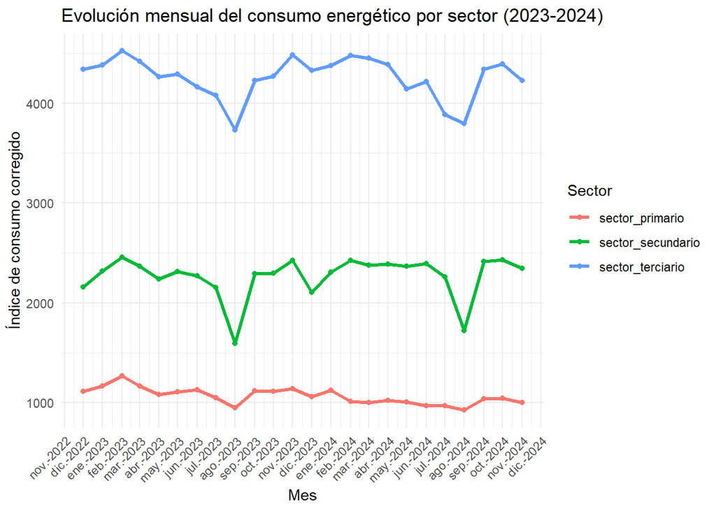

```r
library(ggplot2)
library(gridExtra)
library(dplyr)
library(tidyr)
library(tidyverse)
library(cluster)
library(factoextra)
library(ggsci)
library(shiny)
library(sf)
library(rnaturalearth)
library(rnaturalearthdata)
ire_sectores <- read_csv("ire_sectores.csv")
ire_sectores2015 <- read_csv("ire_sectores2015.csv")
datos_europa <- read_csv("datos_europa.csv")
datos_clustering <- read_csv("datos_clustering.csv")
# Paso 2: Graficar usando 'Mes_fecha' en el eje x
ggplot(ire_sectores, aes(x = Mes_fecha, y = `Indice sector`, color = Sector, group = Sector)) +
  geom_line(size = 1.2) +
  geom_point() +
  theme_minimal() +
  labs(title = "Evolución mensual del consumo energético por sector (2023-2024)",
       x = "Mes",
       y = "Índice de consumo corregido",
       color = "Sector") +
  scale_x_date(date_labels = "%b-%Y", date_breaks = "1 month") +
  theme(axis.text.x = element_text(angle = 45, hjust = 1))
```

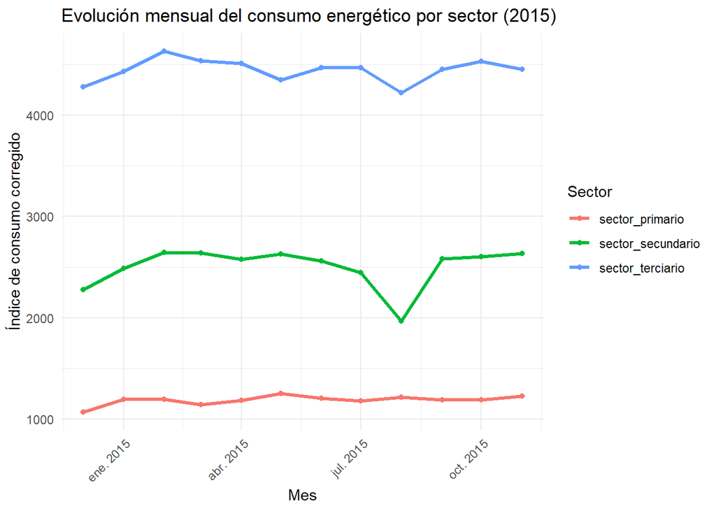

```r
ggplot(ire_sectores2015, aes(x = Mes_fecha, y = `Indice sector`, color = Sector, group = Sector)) +
  geom_line(size = 1.2) +
  geom_point() +
  theme_minimal() +
  labs(title = "Evolución mensual del consumo energético por sector (2015)",
       x = "Mes",
       y = "Índice de consumo corregido",
       color = "Sector") +
  theme(axis.text.x = element_text(angle = 45, hjust = 1))
```

En primer lugar, lo que más se puede destacar es que el verano representa el periodo de menor consumo energético, destacando especialmente el mes de agosto, cuando todos los sectores muestran una caída pronunciada. Este comportamiento es coherente con las vacaciones estivales y los cierres temporales, especialmente en los sectores secundario y terciario. Seguidamente, el sector terciario es el mayor consumidor de energía a lo largo de todo el periodo analizado. Su consumo se mantiene relativamente estable, con valores que oscilan entre los 4.200 y 4.500 puntos excepto en los periodos vacionales. En cuanto al sector secundario es el segundo mayor consumidor de energía por detrás del sector terciario y su consumo es el que más varia de los tres. Esto se debe a que las actividades industriales suelen ajustarse a la demanda del mercado, lo que provoca aumentos o reducciones estacionales en su producción. Por último, vemos un sector primario con poca influencia en el consumo eléctrico en España. Al compararlo con el consumo del 2015, no hay grandes diferencias remarcables a primera vista. No obstante, se aprecia una ligera disminución del consumo energético en la industria, lo cual podría deberse a una desindustrialización parcial en algunos sectores específicos

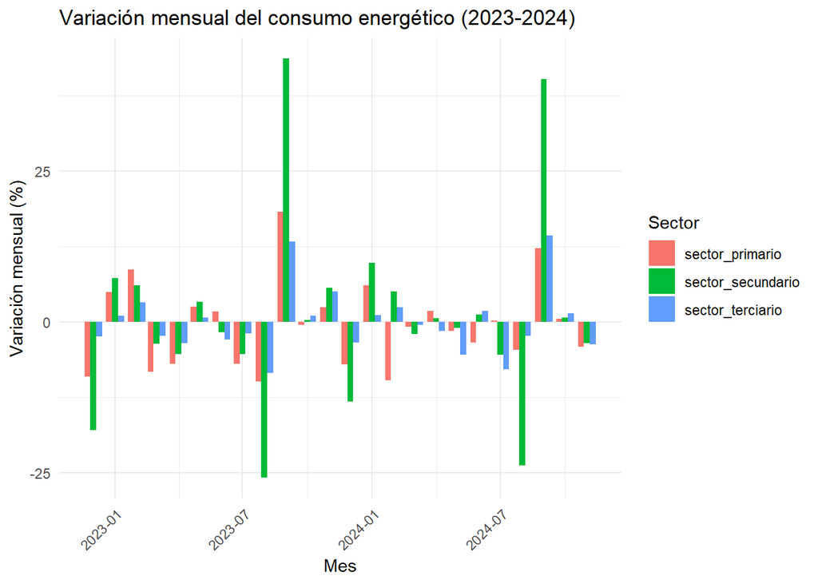

```r
ggplot(ire_sectores, aes(x = Mes_fecha, y =variacion_mensual, fill = Sector)) +
  geom_col(position = "dodge") +
  theme_minimal() +
  labs(title = "Variación mensual del consumo energético (2023-2024)",
       x = "Mes",
       y = "Variación mensual (%)") +
  theme(axis.text.x = element_text(angle = 45, hjust = 1))
```

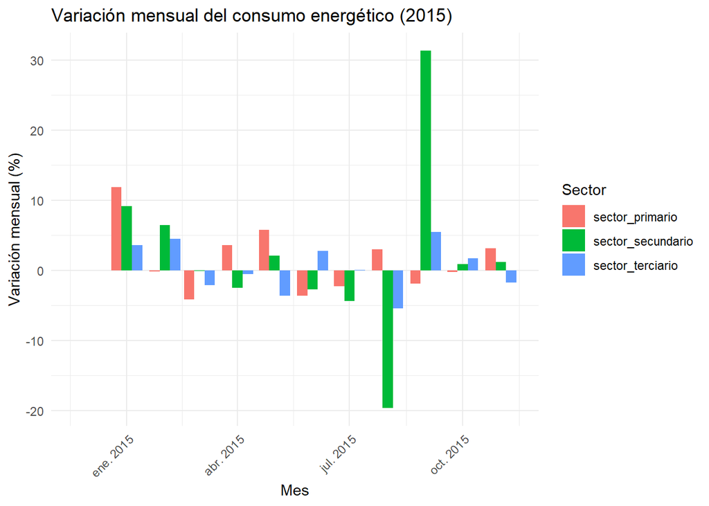

```r
ggplot(ire_sectores2015, aes(x = Mes_fecha, y = variacion_mensual, fill = Sector)) +
  geom_col(position = "dodge") +
  theme_minimal() +
  labs(title = "Variación mensual del consumo energético (2015)",
       x = "Mes",
       y = "Variación mensual (%)") +
  theme(axis.text.x = element_text(angle = 45, hjust = 1))
```

Este diagrama de barras muestra con mayor claridad la variabilidad mensual en el consumo energético de cada sector. Observamos una gran variabilidad del sector secundario. Esto se debe a que las actividades industriales suelen ajustarse a la demanda del mercado, lo que provoca aumentos o reducciones estacionales en su producción.

A continuación, pasaremos a comparar el consumo energético de España con el del resto de la Unión Europea. Para empezar, veremos de manera visual cuales son los países que más consumen para después verlo de la misma manera a partir de la visualización por mapas

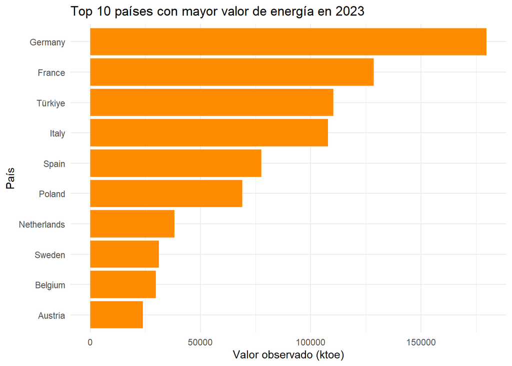

```r
anio_seleccionado <- 2023

# Filtramos los datos por año y tomamos el top 10
top10 <- datos_europa %>%
  filter(TIME_PERIOD == anio_seleccionado) %>%
  arrange(desc(OBS_VALUE)) %>%
  slice_head(n = 10)

# Creamos el grafico de barras
ggplot(top10, aes(x = reorder(geo, OBS_VALUE), y = OBS_VALUE)) +
  geom_col(fill = "darkorange") +
  coord_flip() +
  labs(
    title = paste("Top 10 países con mayor valor de energía en", anio_seleccionado),
    x = "País",
    y = "Valor observado (ktoe)"
  ) +
  theme_minimal()
```

```r
# Mapa de Europa
europe <- ne_countries(scale = "medium", returnclass = "sf") %>%
  filter(region_un == "Europe")

# Interfaz de usuario
ui <- fluidPage(
  titlePanel("Mapa interactivo de valores por país en Europa"),
  sidebarLayout(
    sidebarPanel(
      selectInput("anio", "Selecciona el año:",
                  choices = sort(unique(datos_europa$TIME_PERIOD)),
                  selected = 2023)
    ),
    mainPanel(
      plotOutput("mapa", height = "600px", width = "100%")
    )
  )
)

# Lógica del servidor (genera dinámicamente el mapa en base al año seleccionado)
server <- function(input, output) {
  output$mapa <- renderPlot({
    # Filtrar datos por año seleccionado
    datos_filtrados <- datos_europa %>% filter(TIME_PERIOD == input$anio)

    # Combinar con mapa
    mapa_europa <- europe %>%
      left_join(datos_filtrados, by = c("name" = "geo"))

    # Graficar
    ggplot(data = mapa_europa) +
      geom_sf(aes(fill = OBS_VALUE)) +
      scale_fill_gradient(name = "Valor observado",
                          low = "lightyellow", high = "darkred", na.value = "grey90") +
      labs(title = paste("Mapa de calor - Año:", input$anio),
           subtitle = "Coloreado según OBS_VALUE",
           caption = "Unión Europea") +
      coord_sf(xlim = c(-25, 45), ylim = c(34, 72), expand = FALSE) +
      theme_minimal()
  })
}

# Ejecutar la aplicación
shinyApp(ui = ui, server = server)
```

Shiny applications not supported in static R Markdown documents

A continuación, intentaremos observar como se agrupan los países de la base de datos en función de sus tendencias en el consumo energético. Al querer buscar la tendencia y no la cantidad, usaremos medidas de distancia basadas en correlación. En este caso, usaremos el coeficiente de Spearman

Para empeszar, vamos a decidir en cuantos clusters dividir el análisis según diferentes métodos:

METODO DE WARD

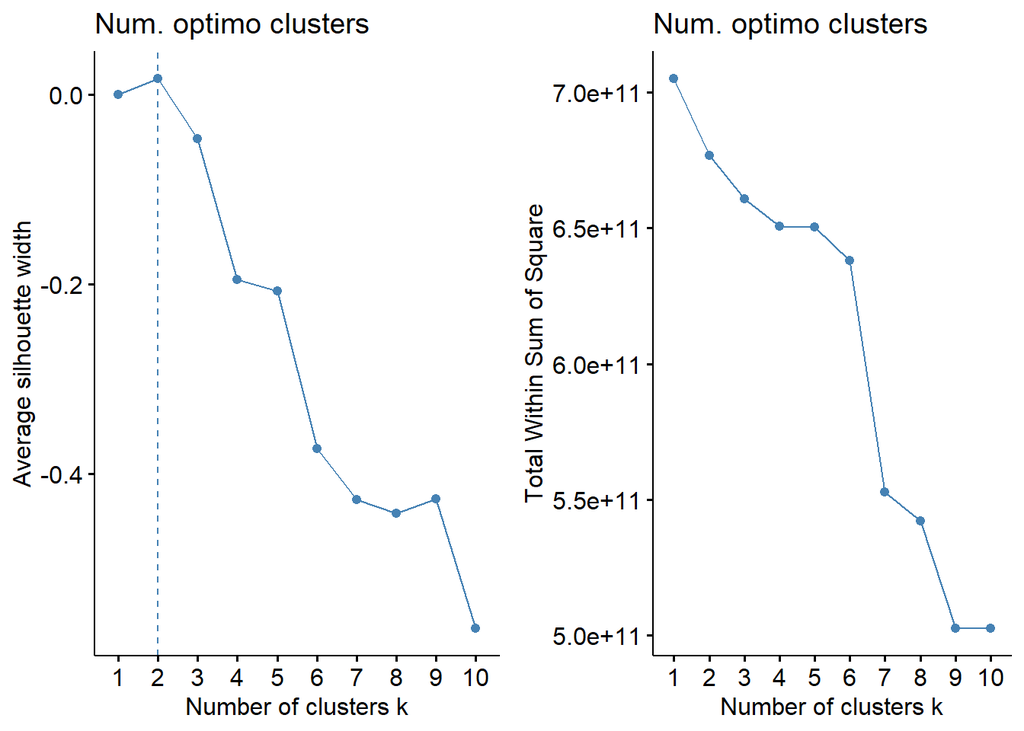

```r
p1 = fviz_nbclust(x = datos_clustering, FUNcluster = hcut, method = "silhouette",
                  hc_method = "ward.D2", k.max = 10, verbose = FALSE,
                  hc_metric = "spearman") + labs(title = "Num. optimo clusters")
p2 = fviz_nbclust(x = datos_clustering, FUNcluster = hcut, method = "wss",
                  hc_method = "ward.D2", k.max = 10, verbose = FALSE,
                  hc_metric = "spearman") + labs(title = "Num. optimo clusters")
grid.arrange(p1, p2, nrow = 1)
```

A pesar de que la suma de cuadrados no es demasiado baja, el punto óptimo del coeficiente de Silhouette es cuando k = 2. De momento, fijaremos el número de clusters en 2

```r
midist <- get_dist(datos_clustering, stand = FALSE, method = "spearman")
clust1 <- hclust(midist, method="ward.D2")
grupos1 <- cutree(clust1, k=2)
table(grupos1)
```

```
## grupos1
##  1  2
## 21 19
```

Se darían dos clusters bastante equilibrados

K-MEDIAS

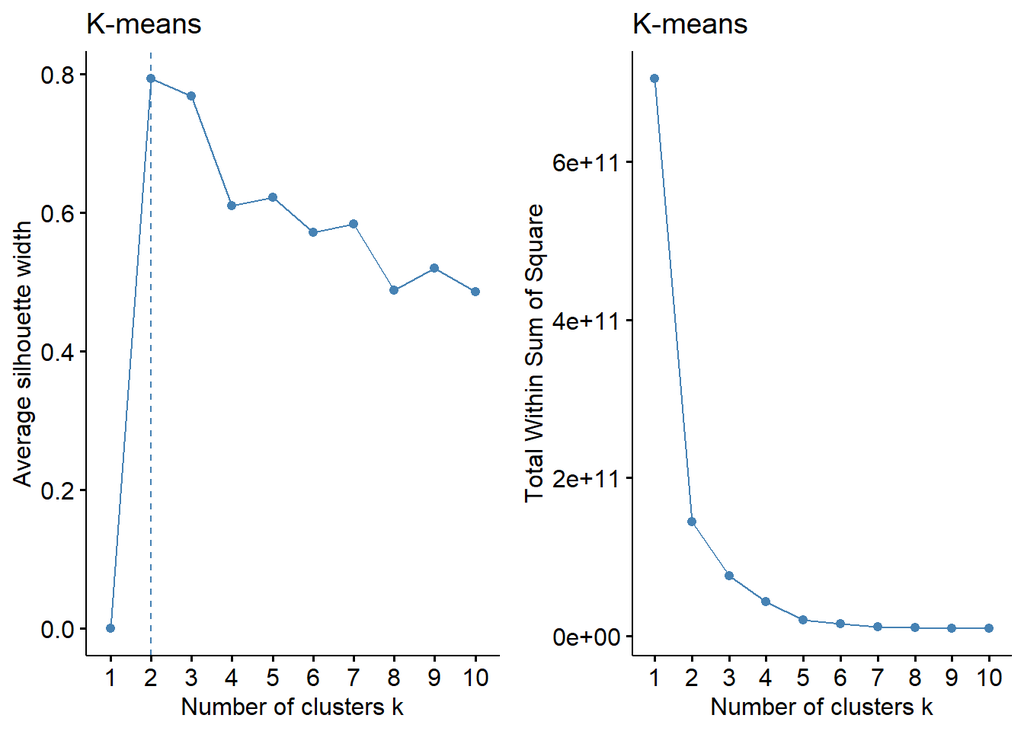

```r
p1 = fviz_nbclust(x = datos_clustering, FUNcluster = kmeans, method = "silhouette",
             k.max = 10, verbose = FALSE) +
  labs(title = "K-means")
p2 = fviz_nbclust(x = datos_clustering, FUNcluster = kmeans, method = "wss",
             k.max = 10, verbose = FALSE) +
  labs(title = "K-means")
grid.arrange(p1, p2, nrow = 1)
```

Aquí se observa claramente que el número de clusters idóneo es 2 para ambas gráficas, así que nos quedamos con 2 clusters

```r
set.seed(100)
clust2 <- kmeans(datos_clustering, centers = 2)
table(clust2$cluster)
```

```
##
##  1  2
## 33  7
```

Este cluster no saldría muy equilibrado, entonces no será muy conveniente

K-MEDOIDES

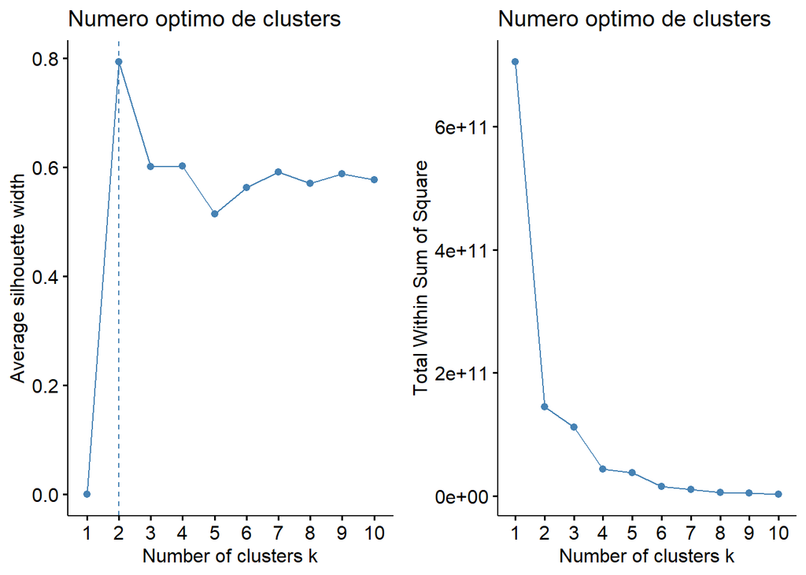

```r
p1 = fviz_nbclust(x = datos_clustering, FUNcluster = pam, method = "silhouette",
             k.max = 10, verbose = FALSE) +
  labs(title = "Numero optimo de clusters")
p2 = fviz_nbclust(x = datos_clustering, FUNcluster = pam, method = "wss",
             k.max = 10, verbose = FALSE) +
  labs(title = "Numero optimo de clusters")
grid.arrange(p1, p2, nrow = 1)
```

Ocurre lo mismo que en el anterior caso. El número de clusters óptimo es 2 para ambas gráficas.

```r
clust3 <- pam(datos_clustering, k = 2)
table(clust3$clustering)
```

```
##
##  1  2
## 33  7
```

Lo mismo que para el anterior método. Observaremos que método usar mediante la evualuación de Silhouette

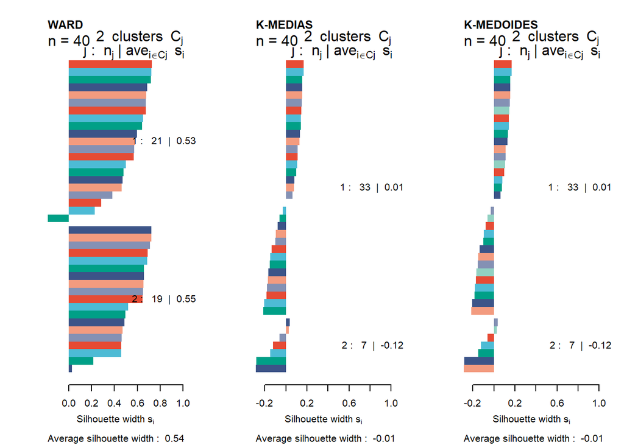

```r
colores = pal_npg("nrc")(6)
colores2 = pal_npg("nrc")(7)
par(mfrow = c(1,3))
plot(silhouette(grupos1, midist), col=colores, border=NA, main = "WARD")
plot(silhouette(clust2$cluster, midist), col=colores, border=NA, main = "K-MEDIAS")
plot(silhouette(clust3$clustering, midist), col=colores2, border=NA, main = "K-MEDOIDES")
```

A la vista de los coeficientes Silhouette, el mejor resultado es para el algoritmo de ward, ya que presenta menos datos con coeficiente negativo

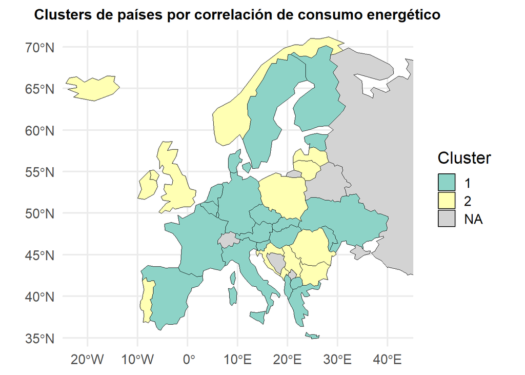

```r
df_inicial <- datos_europa %>%
  tidyr::pivot_wider(names_from = TIME_PERIOD, values_from = OBS_VALUE)
View(df_inicial)
# Establecer k = 2
hc_ward <- hclust(midist, method="ward.D2")
grupos_finales <- cutree(hc_ward, k = 2)
df_inicial$cluster_cor <- factor(grupos_finales)
mapa_europa <- ne_countries(continent = "Europe", returnclass = "sf")

# Unir clusters al shapefile
mapa_clusters_cor <- mapa_europa %>%
  left_join(df_inicial %>% select(geo, cluster_cor), by = c("name" = "geo"))

# Dibujar el mapa
ggplot(mapa_clusters_cor) +
  geom_sf(aes(fill = cluster_cor), color = "black") +
  scale_fill_brewer(palette = "Set3", na.value = "lightgrey") +
  coord_sf(xlim = c(-25, 45), ylim = c(34, 72), expand = FALSE) +
  theme_minimal(base_size = 16) +
  labs(
    title = "Clusters de países por correlación de consumo energético",
    fill = "Cluster"
  ) +
  theme(
    plot.title = element_text(size = 14, face = "bold", hjust = 0.5),
    legend.position = "right"
  )
```

Primer cluster: algunos países como Francia, España y Alemania han diversificado su matriz energética en las últimas décadas con energías renovables, pero manteniendo también fuentes fósiles o nucleares. Varios de estos países forman parte de la zona central y sur de la UE, y han compartido políticas energéticas y de descarbonización. Suecia y Finlandia parecen ser casos especiales sin embargo, aunque son nórdicos, tienen una industrialización similar al centro europeo y una producción de renovables sostenida.